# Session 1: Prior, likelihood and prior predictive distributions

# 1 Statistical model

A statistical model , $M$, is a set of **probability models** indexed by a parameter that is known to belong to a **parameter space** $\Omega$.

$$M = \{P(y | \theta), \theta \in
\Omega\}.$$

When we do **inference**, we assume that data $Y = y$ is coming from a probability model $P(y| \theta^{*})$ that is known to belong to $M$. We assume that $\theta^{*} \in \Omega$.

$$Y | \theta \sim P(y|
\theta)$$

> **Example:**

> Which would be the statistical model in:
> - Tossing a coin 20 times, how many tails?
> - Choose 20 random places in the world and see how many times it is land (or sea)?

$$M = \{Binomial(n = 20, \theta), \theta
\in [0,1]\}$$

> **Exercise:**

> How would you plot the previous statistical model?

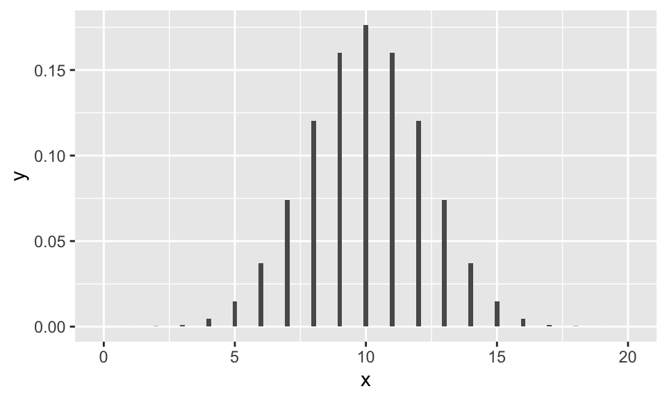

```r
library(ggplot2)
library(dplyr)

# Plot binomial distribution
# a) By definition
df <- tibble(x = 0:20)
ggplot(df, aes(x)) +
  stat_function(fun = dbinom,
    args = list(size = 20, prob = 0.5),
    geom = "bar")
```

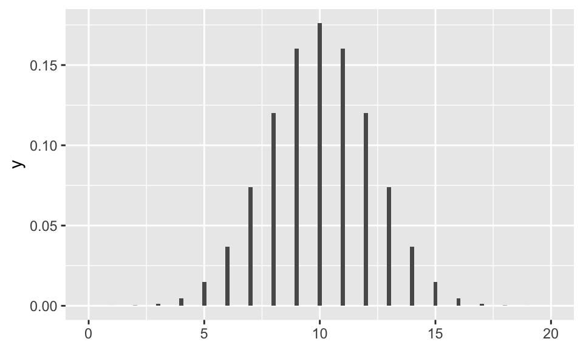

```r
ggplot() +
  stat_function(fun = dbinom,
                args = list(size = 20, prob = 0.5),
                geom = "bar") +
  xlim(c(0, 20))
```

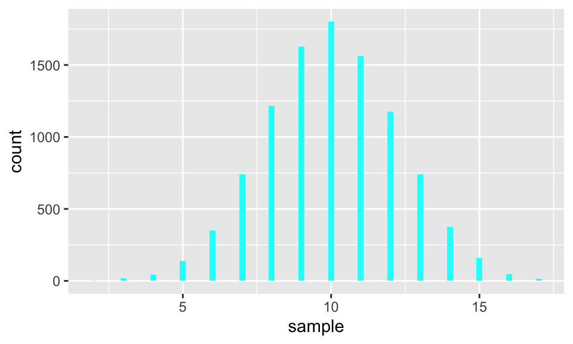

```r
# b) Sampling
sample <- rbinom(p=0.5, size=20, n=10000)
ggplot(tibble(sample))+
  geom_bar(aes(sample), fill="cyan",width = 0.2)
```

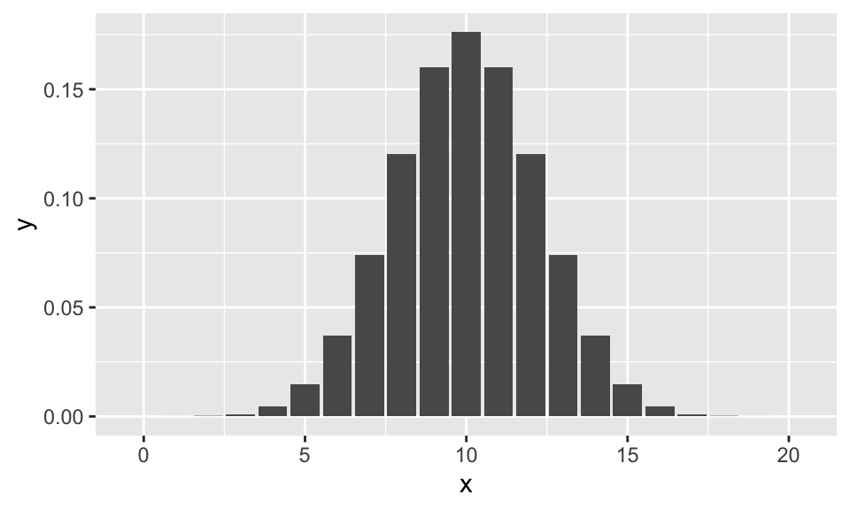

```r
# c) Tibble
sample <- tibble(
  x = 0:20,
  y = dbinom(x, 20, 0.5)
)
ggplot(sample) +
  geom_bar(aes(x, y), stat = "identity")
```

> **Exercise 1.5**

> **Goals**. Choose a Bayesian model for the number of goals scored in a match in the first division of the Spanish soccer league, and argue in favor of it.

# 2 Prior distribution: $\Pi(\theta)$

A bayesian also starts with a statistical model:

$M = \{P(y | \theta), \theta \in \Omega\}$.

- Consider $\theta$ as a random variable
- Choose a distribution on $\Omega$ for $\theta$ that captures your information about $\theta$ **before observing data**
- $\Pi(\theta)$ is the prior distribution

If $V(\theta)$ is large $\Leftrightarrow$ $\Pi(\theta)$ less informative  
If $V(\theta)$ is small $\Leftrightarrow$ $\Pi(\theta)$ is very informative

# 3 Bayesian Model: $M + \Pi(\theta)$

Bayesian model : list of probability models, ${P(y|\theta), \theta \in \Omega}$ ranked from more credible to least credible based on the values taken by $\Pi(\theta)$.

> **Exercise:**

> What prior distribution would you use in this case?  
> - Tossing a coin

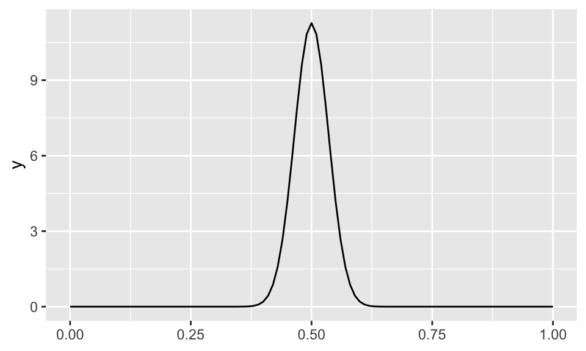

```r
ggplot() +
  stat_function(fun = dbeta,
                args = list(shape1 = 100, shape2 = 100)) +
  xlim(c(0, 1))
```

## 3.1 Beta distribution

A family of distributions that are suported on [0,1] that are convenient are $Beta(\alpha, \beta)$ disribution. $0< \alpha, \beta < \infty$

$\alpha>1, \beta>1$: Shape $\cap$  
$\alpha>1, \beta<1$: Shape /  
$\alpha<1, \beta>1$: Shape \  
$\alpha<1, \beta<1$: Shape V

**Interpretation:**

$Beta(\alpha, \beta)$: what you know is equivalent to tossing a coin $n=\alpha + \beta$ times and observing $\alpha$ heads and $\beta$ tails.

$$E(\theta) = \frac{\alpha}{\alpha +
\beta}$$
$$V(\theta)=\frac{\alpha \cdot \beta}{(\alpha
+ \beta)^2 (\alpha + \beta +1)}$$

> **Exercise:**

> What prior distribution would you use in this case?  
> - Choose a random place in the world and see if it is land or sea

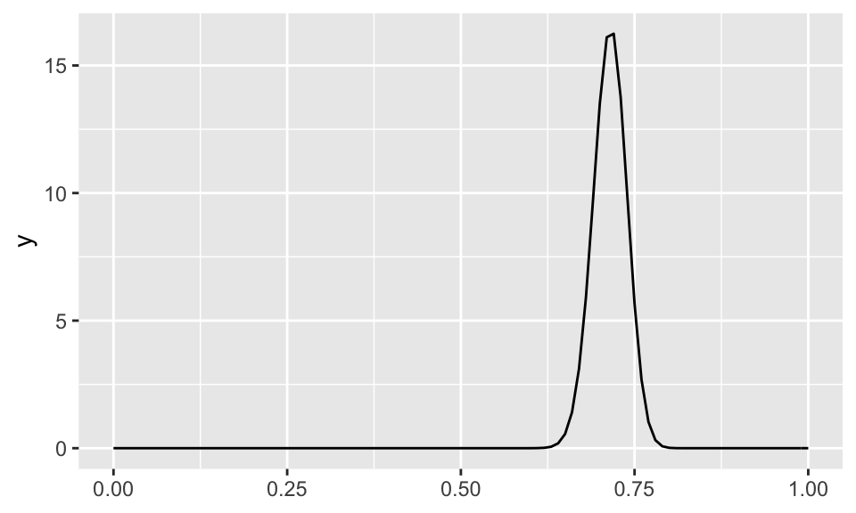

```r
ggplot() +
  stat_function(fun = dbeta,
                args = list(shape1 = 250, shape2 = 100)) +
  xlim(c(0, 1))
```

# 4 Likelihood function

Before data, if we fix $\theta$, the statistical model $M=\{P(y|\theta), \theta \in \Omega\}$ becomes a probabilistic model (a function of $y$).

Once you have data $Y=y$ you can switch things around. Then $P(y| \theta)$ is a function of $\theta$. This is the likelihood function : $\ell_{Y=y}(\theta) \propto p(y | \theta)$

> **Example:**
> - Suppose we throw the coin 20 times and get 12 tails

$$l_y(\theta) \propto {20 \choose 12}
\theta^{12} (1- \theta)^{20-12}$$

The likelihood function orders the values in $\Omega$ from the more likely to the least likely.

**Prior - likelihood**: the **difference** is that you have a prior $\Pi(\theta)$ without the need of data. You can not have a likelihood function without data.

> **Exercise:**

> Plot the previous likelihood function

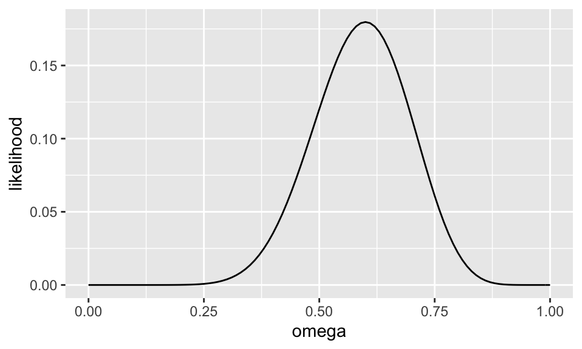

```r
# dbinom(x, size, prob, log = FALSE)
df <- tibble(
  omega = seq(0, 1, 0.01),
  likelihood = dbinom(12, 20, omega))

ggplot(df) +
  geom_line(aes(omega, likelihood))
```

# 5 Prior predictive distribution: $P_{\Pi} (\tilde y)$

What do you do if you care about future values of $y$, $\tilde y$?

What do we know about $\tilde y$ before answering the data?

$\left\{\begin{matrix} M = \{p(\tilde y | \theta), \theta \in \Omega\} \\ \pi(\theta) \end{matrix}\right.$

If you assume this, what is your best bet as a distribution of $\tilde y$?

$P_{\pi}(\tilde y) = \int_{\Omega}{p(\tilde y | \theta)\pi(\theta) d\theta} = E_{\pi}(p(\tilde y | \theta))$ is the prior predictive distribution .

$p(\tilde y | \theta)$ is the weighted average of $p(y | \theta)$

This is what you will use if you want to predict $\tilde y$ without data.

> **Exercise:**

$$Y|p \sim Binomial(n=20, p)$$
$$p \sim Beta(a=200, b=200)$$

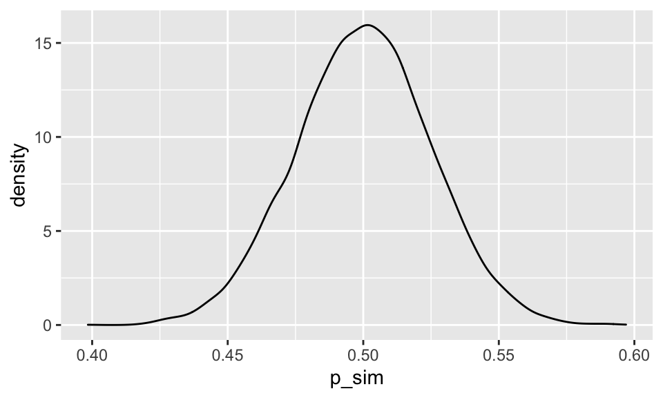

```r
## Predictive simulation

# Simulate 10000 draws from prior density: p_sim
p_sim <- rbeta(10000, 200, 200)
ggplot(tibble(p_sim)) +
  geom_density(aes(p_sim))
```

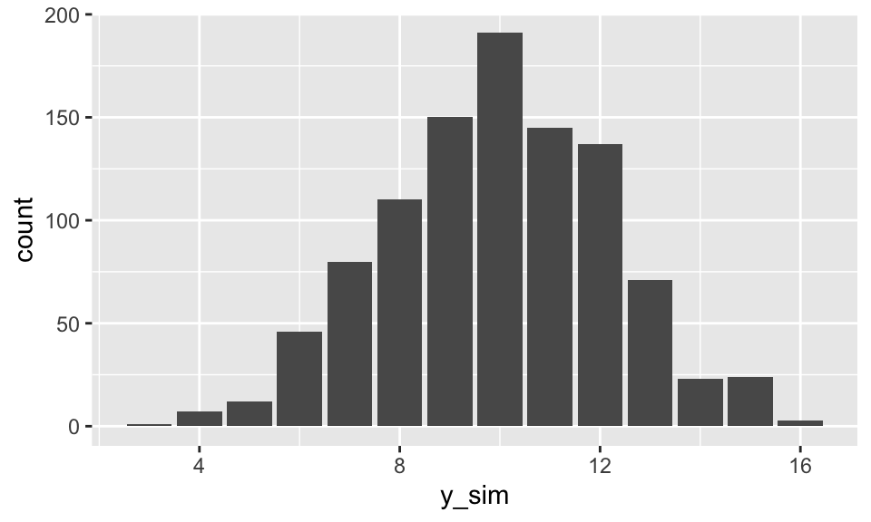

```r
# Simulate 10000 draws from the predictive density: y_sim
y_sim <- rbinom(1000, 20, p_sim)

# Plot the prior predictive density
ggplot(tibble(y_sim)) +
  geom_bar(aes(y_sim))
```

```r
# Compute the probability of less than 5 tails
mean(y_sim < 5)
```

```
[1] 0.008
```

```r
# Find a 90 percent prediction interval for the number of tails
quantile(y_sim, c(0.05, 0.95))
```

```
   5%   95%
 6.00 13.05
```

> **Exercise 1.4**